# NON LINEAR REGRESSION MODELS

# Objective

This homework sheet will help reviewing the basic concepts associated with non-linear models. Please review the lectures, suggested readings, and additional resources *before* getting started on the HW.

**Some questions in this assignment will require you to conduct independent research beyond the material covered in the recorded content.**

**Some of the libraries / links mentioned in APPLIED questions are only for your reference. Unless specifically indicated, feel free to utilise any Python library of your choice to carry out the assignment questions**

PYGAM REFERENCE LINK:

https://pygam.readthedocs.io/en/latest/notebooks/tour_of_pygam.html

STATSMODELS REFERENCE LINK:

https://www.statsmodels.org/dev/glm.html

PATSY REFERENCE LINK:

https://patsy.readthedocs.io/en/latest/

The following website has access to the relevant datasets from the recommended textbook: https://book.huihoo.com/introduction-to-statistical-learning/data.html

Marks Distribution

| Question | Marks |
| --- | --- |
| 1a | 0.5 |
| 1b | 0.5 |
| 1c | 0.5 |
| 1d | 0.5 |
| 1e | 0.5 |
| 2 | 1 |
| 3 | 1 |
| 4 | 1 |
| 5a | 0.5 |
| 5b | 0.5 |
| 5c | 0.5 |
| 6a | 2 |
| 6b | 1 |
| 7a | 1 |
| 7b | 2 |
| 7c | 1 |
| 7d | 1 |

# Conceptual

## Question 1

Suppose that a curve $\hat{g}$ is computed to smoothly fit a set of `n` points using the following formula:

$$ \hat{g} = \arg\min_{g}(\sum_{i=1}^n (y_i - g(x_i))^2 + \lambda \int [g^{(m)} (x)]^2 dx ) $$ where $g^{(m)}$ represents the $m^{th}$ derivative of $g$ (and $g^{(0)} = g$. Provide a description (or sketch) of $\hat{g}$ in each of the following scenarios. where $g^{(m)}$ represents the m th derivative of g

(a) $\lambda$ = $\infty$, $m = 0$.

**ANSWER**

When λ to infinity and m to 0 prioritizes smoothness over fitting the actual data points. This results in very flat and generic curve that may not accurately represent the data's trends. This approach is useful to avoid overfitting or when aiming for an exceptionally smooth function but requires careful selection of λ to balance these aspects.

(b) $\lambda$ = $\infty$, $m = 1$.

**ANSWER**

When λ to infinity with m to 1 prioritizes a very smooth slope over precisely fitting the data. This creates a curve with minimal bumps and sharp turns even if it deviates from some data points. This approach is useful to avoid overfitting and ensure a gentle trend but requires balancing λ for optimal results.

(c) $\lambda$ = $\infty$, $m = 2$.

**ANSWER**

When λ to infinity and m to 2 prioritizes smoothness over data fidelity. This results in a very smooth curve with minimal bends, but it might not perfectly capture the actual data trends. This approach is useful for avoiding overfitting or ensuring a curve with no sharp turns like a smooth hill.

(d) $\lambda$ = $\infty$, $m = 3$.

**ANSWER**

When λ to infinity with m=3 prioritizes extreme smoothness, particularly in the curve's third-order changes. This approach prioritizes a smooth and gentle curve like a perfect road, even if it deviates from the data. While useful to avoid overfitting or ensure a curve with no sharp kinks it may not accurately capture the data's details.

(e) $\lambda$ = 0, $m = 3$.

**ANSWER**

When λ set to 0 and m equal to 3 curve smoothness is completely unrestricted. The sole focus is on achieving the best possible fit to the data. This prioritizes capturing every detail and fluctuation in the data points even if it results in a curve with sharp turns and rapid changes. This approach is ideal when accurately reflecting the data is the top priority even if smoothness comes secondary.

## Question 2

For (1) step functions, (2) local regression, and (3) GAMs: provide one situation when using that particular model is advantageous. For instance, “GAMs is likely the preferred option when the question I’m interested in addressing involves…”.

**ANSWER**

1. **Step functions**: Step functions are advantageous when dealing with categorical or ordinal predictor variables. For instance when analyzing the effect of different levels of education (such as high school, bachelor's, master's, etc.) on income levels using step functions can capture the abrupt changes or steps in income that occur at each level of education.
2. **Local regression**: Local regression is beneficial in scenarios where the relationship between variables is expected to vary across different regions of the data space. For example in analyzing temperature patterns across a geographical region local regression can capture the varying relationships between temperature and altitude, latitude or proximity to bodies of water which may differ in different areas.
3. **GAMs (Generalized Additive Models)**: GAMs are likely the preferred option when the question of interest involves nonlinear relationships between predictors and the response variable. For instance when studying the impact of environmental factors (like temperature, humidity, pollution levels) on public health outcomes (such as asthma prevalence) GAMs can flexibly model nonlinear relationships without assuming a specific functional form allowing for more accurate representation of complex relationships.

## Question 3

Define the following types of smooth functions from PYGAM library (https://pygam.readthedocs.io/en/latest/notebooks/tour_of_pygam.html ) and list at least one relevant potential use:

a) l() linear terms

b) s() spline terms

c) f() factor terms

d) te() Tensor product interaction terms

**l() linear terms:** can be used to model linear relationships between a feature and the dependent variable.

For example, you could use a linear term to model the effect of age on wages.

**s() spline terms:** can be used to model non-linear relationships between a feature and the dependent variable.

For example, you could use a spline term to model the effect of temperature on crop yield.

**f() factor terms:** can be used to model the effect of categorical variables on the dependent variable.

For example, you could use a factor term to model the effect of fertilizer type on crop yield.

**te() tensor product interaction terms:** can be used to model the interaction between two or more features.

For example, you could use a tensor product interaction term to model the interaction between temperature and rainfall on crop yield.

## Question 4

Briefly explain what spatial and temporal autocorrelation are? List one way in which GAMs could help to account for this (e.g. indicate the type of smooth function you would use or potential types of correlation structures).

**ANSWER**

Spatial autocorrelation is when nearby locations in a dataset show higher similarity seen in environmental studies like temperature measurements.

Temporal autocorrelation is seen between observations at close time points as with stock prices in financial analysis.

In GAMs, spatial smooths like thin-plate splines handle spatial autocorrelation, while temporal trends are addressed using cyclic cubic splines or penalized regression splines.

These smooth functions allow GAMs to capture spatial and temporal patterns, accounting for autocorrelation in the data.

## Question 5

Consider two curves $\hat{g}1$ and $\hat{g}2$, defined by

$$ \hat{g}1 = \arg\min_{g}(\sum_{i=1}^n (y_i - g(x_i))^2 + \lambda \int [g^{(3)} (x)]^2 dx ) $$

$$ \hat{g}2 = \arg\min_{g}(\sum_{i=1}^n (y_i - g(x_i))^2 + \lambda \int [g^{(4)} (x)]^2 dx ) $$

where $g^{(m)}$ represents the $m^{th}$ derivative of $g$. Now, answer the following questions (and include a brief explanation):

a) As $\lambda \rightarrow \infty$, will $\hat{g}1$ or $\hat{g}2$ have smaller training RSS?

**ANSWER**

For the above condition, 𝜆 becomes very large 𝑔̂1 will have a smaller training error (RSS) compared to 𝑔̂2.

While 𝜆 is very large it strongly disagrees the complexity of the curve.

Above provided scenario, 𝑔̂1, which involves a third derivative (𝑔(3)(𝑥)) which is **simpler and smoother** than 𝑔̂2 which involves a fourth derivative (𝑔(4)(𝑥)).

**The (g(4)(x)) captures more complex and rapid changes in the curve.**

So, 𝑔̂2 will have a larger training error than 𝑔̂1 because it strongly disagrees for being more complex.

b) As $\lambda \rightarrow \infty$, will $\hat{g}1$ or $\hat{g}2$ have smaller test RSS?

**ANSWER**

For the above condition, 𝜆 becomes very large both 𝑔̂1 and 𝑔̂2 will likely have smaller test errors (RSS).

While 𝜆 is very large it forces the models to be **simple and smooth**.

Both 𝑔̂1 and 𝑔̂2 will have smoother and straight curves which result in *smaller test errors*.

*The models are restricted to be very simple which generally reduces the test error*.

c) For $\lambda= 0$, will $\hat{g}1$ or $\hat{g}2$ have smaller training RSS?

**ANSWER**

For the above condition, 𝜆=0 both 𝑔̂1 and 𝑔̂2 will have the same training RSS and no change in them.

While 𝜆 is set to 0 there is no changes applied to the models.

Both 𝑔̂1 and 𝑔̂2 are free to fit the training data without any rules.

Due to which the training RSS will be the same.

APPLIED

## Question 6

This question relates to the `College` data set.

pre process the data if required

a) Fit a GAM on the training data, using out-of-state tuition as the response and only subset of features as the predictors ( Select 'private', 'Room.Board' , 'PhD' , 'perc.alumni' , 'Expend' , 'Grad.rate' ) Plot the results and briefly explain your findings

**ANSWER**

```python
!pip install pygam
```

```
     ━━━━━━━━━━━━━━━━━━━━━━━━━━━━━━━━━━━━━━━━ 522.0/522.0 kB 4.0 MB/s eta 0:00:00
```

```python
import pandas as pd
import numpy as np
import matplotlib.pyplot as plt
from pygam import LinearGAM
from sklearn.model_selection import train_test_split
from sklearn.preprocessing import LabelEncoder
```

```python
df = pd.read_csv('College.csv')
df.head()
```

|  | Unnamed: 0 | Private | Apps | Accept | Enroll | Top10perc | Top25perc | F.Undergrad | P.Undergrad | Outstate | Room.Board | Books | Personal | PhD | Terminal | S.F.Ratio | perc.alumni | Expend | Grad.Rate |
| --- | --- | --- | --- | --- | --- | --- | --- | --- | --- | --- | --- | --- | --- | --- | --- | --- | --- | --- | --- |
| 0 | Abilene Christian University | Yes | 1660 | 1232 | 721 | 23 | 52 | 2885 | 537 | 7440 | 3300 | 450 | 2200 | 70 | 78 | 18.1 | 12 | 7041 | 60 |
| 1 | Adelphi University | Yes | 2186 | 1924 | 512 | 16 | 29 | 2683 | 1227 | 12280 | 6450 | 750 | 1500 | 29 | 30 | 12.2 | 16 | 10527 | 56 |
| 2 | Adrian College | Yes | 1428 | 1097 | 336 | 22 | 50 | 1036 | 99 | 11250 | 3750 | 400 | 1165 | 53 | 66 | 12.9 | 30 | 8735 | 54 |
| 3 | Agnes Scott College | Yes | 417 | 349 | 137 | 60 | 89 | 510 | 63 | 12960 | 5450 | 450 | 875 | 92 | 97 | 7.7 | 37 | 19016 | 59 |
| 4 | Alaska Pacific University | Yes | 193 | 146 | 55 | 16 | 44 | 249 | 869 | 7560 | 4120 | 800 | 1500 | 76 | 72 | 11.9 | 2 | 10922 | 15 |

```python
df.info()
```

```
<class 'pandas.core.frame.DataFrame'>
RangeIndex: 777 entries, 0 to 776
Data columns (total 19 columns):
 #   Column       Non-Null Count  Dtype
---  ------       --------------  -----
 0   Unnamed: 0   777 non-null    object
 1   Private      777 non-null    object
 2   Apps         777 non-null    int64
 3   Accept       777 non-null    int64
 4   Enroll       777 non-null    int64
 5   Top10perc    777 non-null    int64
 6   Top25perc    777 non-null    int64
 7   F.Undergrad  777 non-null    int64
 8   P.Undergrad  777 non-null    int64
 9   Outstate     777 non-null    int64
 10  Room.Board   777 non-null    int64
 11  Books        777 non-null    int64
 12  Personal     777 non-null    int64
 13  PhD          777 non-null    int64
 14  Terminal     777 non-null    int64
 15  S.F.Ratio    777 non-null    float64
 16  perc.alumni  777 non-null    int64
 17  Expend       777 non-null    int64
 18  Grad.Rate    777 non-null    int64
dtypes: float64(1), int64(16), object(2)
memory usage: 115.5+ KB
```

```python
df.describe()
```

|  | Apps | Accept | Enroll | Top10perc | Top25perc | F.Undergrad | P.Undergrad | Outstate | Room.Board | Books | Personal | PhD | Terminal | S.F.Ratio | perc.alumni | Expend | Grad.Rate |
| --- | --- | --- | --- | --- | --- | --- | --- | --- | --- | --- | --- | --- | --- | --- | --- | --- | --- |
| count | 777.000000 | 777.000000 | 777.000000 | 777.000000 | 777.000000 | 777.000000 | 777.000000 | 777.000000 | 777.000000 | 777.000000 | 777.000000 | 777.000000 | 777.000000 | 777.000000 | 777.000000 | 777.000000 | 777.00000 |
| mean | 3001.638353 | 2018.804376 | 779.972973 | 27.558559 | 55.796654 | 3699.907336 | 855.298584 | 10440.669241 | 4357.526384 | 549.380952 | 1340.642214 | 72.660232 | 79.702703 | 14.089704 | 22.743887 | 9660.171171 | 65.46332 |
| std | 3870.201484 | 2451.113971 | 929.176190 | 17.640364 | 19.804778 | 4850.420531 | 1522.431887 | 4023.016484 | 1096.696416 | 165.105360 | 677.071454 | 16.328155 | 14.722359 | 3.958349 | 12.391801 | 5221.768440 | 17.17771 |
| min | 81.000000 | 72.000000 | 35.000000 | 1.000000 | 9.000000 | 139.000000 | 1.000000 | 2340.000000 | 1780.000000 | 96.000000 | 250.000000 | 8.000000 | 24.000000 | 2.500000 | 0.000000 | 3186.000000 | 10.00000 |
| 25% | 776.000000 | 604.000000 | 242.000000 | 15.000000 | 41.000000 | 992.000000 | 95.000000 | 7320.000000 | 3597.000000 | 470.000000 | 850.000000 | 62.000000 | 71.000000 | 11.500000 | 13.000000 | 6751.000000 | 53.00000 |
| 50% | 1558.000000 | 1110.000000 | 434.000000 | 23.000000 | 54.000000 | 1707.000000 | 353.000000 | 9990.000000 | 4200.000000 | 500.000000 | 1200.000000 | 75.000000 | 82.000000 | 13.600000 | 21.000000 | 8377.000000 | 65.00000 |
| 75% | 3624.000000 | 2424.000000 | 902.000000 | 35.000000 | 69.000000 | 4005.000000 | 967.000000 | 12925.000000 | 5050.000000 | 600.000000 | 1700.000000 | 85.000000 | 92.000000 | 16.500000 | 31.000000 | 10830.000000 | 78.00000 |
| max | 48094.000000 | 26330.000000 | 6392.000000 | 96.000000 | 100.000000 | 31643.000000 | 21836.000000 | 21700.000000 | 8124.000000 | 2340.000000 | 6800.000000 | 103.000000 | 100.000000 | 39.800000 | 64.000000 | 56233.000000 | 118.00000 |

```python
df['Private'] = df['Private'].map({'Yes': 1, 'No': 0})

features = ['Private', 'Room.Board', 'PhD', 'perc.alumni', 'Expend', 'Grad.Rate']

X = df[features]
y = df['Outstate']

X_train, X_test, y_train, y_test = train_test_split(X, y, test_size=0.2, random_state=42)
```

```python
# Fiting a GAM model
gam = LinearGAM().fit(X_train, y_train)
```

[figure not shown]

[figure not shown]

[figure not shown]

[figure not shown]

[figure not shown]

[figure not shown]

```
LinearGAM
=============================================== ==========================================================
Distribution:                        NormalDist Effective DoF:                                      54.762
Link Function:                     IdentityLink Log Likelihood:                                 -9914.2375
Number of Samples:                          621 AIC:                                            19939.9989
                                                AICc:                                           19951.2181
                                                GCV:                                          4062216.6182
                                                Scale:                                        3422962.5932
                                                Pseudo R-Squared:                                   0.8063
==========================================================================================================
Feature Function                  Lambda               Rank         EDoF         P > x        Sig. Code
================================= ==================== ============ ============ ============ ============
s(0)                              [0.6]                20           3.6          1.11e-16     ***
s(1)                              [0.6]                20           11.6         5.76e-09     ***
s(2)                              [0.6]                20           11.7         1.87e-01
s(3)                              [0.6]                20           11.0         2.24e-03     **
s(4)                              [0.6]                20           8.0          1.11e-16     ***
s(5)                              [0.6]                20           9.0          2.41e-04     ***
intercept                                              1            0.0          1.11e-16     ***
==========================================================================================================
Significance codes:  0 '***' 0.001 '**' 0.01 '*' 0.05 '.' 0.1 ' ' 1

WARNING: Fitting splines and a linear function to a feature introduces a model identifiability problem
         which can cause p-values to appear significant when they are not.

WARNING: p-values calculated in this manner behave correctly for un-penalized models or models with
         known smoothing parameters, but when smoothing parameters have been estimated, the p-values
         are typically lower than they should be, meaning that the tests reject the null too readily.
None
```

```python
titles = ['Private', 'Room & Board', 'PhD', 'Alumni Percentage', 'Expenditure', 'Graduation Rate']
for i, term in enumerate(gam.terms):
    if term.isintercept:
        continue
    XX = gam.generate_X_grid(term=i)
    pdep, confi = gam.partial_dependence(term=i, X=XX, width=0.95)

    # Reshaping the confi array
    confi_reshaped = confi.reshape(-1, 2)

    plt.figure()
    plt.plot(XX[:, i], pdep)
    plt.fill_between(XX[:, i], confi_reshaped[:, 0], confi_reshaped[:, 1], alpha=0.2)
    plt.title(titles[i])
    plt.xlabel(f'Partial Dependence on {titles[i]}')
    plt.ylabel('Predicted Outstate')

plt.show()
print(gam.summary())
```

b) For which variables, if any, is there evidence of a non-linear relationship with the response?

**ANSWER**

Private appears to have a linear relationship with the tuition fees while the other factors exhibit non-linear patterns in their relationships with tuition fees.

This suggests that a linear model may not suitable to capture the relationships between these variables and outstate.

The more flexible approach such as GAM would be beneficial for modeling these non-linear relationships.

## Question 7

Answer the questions below using the following dataset (WEEK3_Q7 CSV provided with the learner template):

a) Only by inspecting the plots shown below: Is there any temporal or spatial trend in the response variable `richness`?

```python
from pygam import te
from sklearn.model_selection import train_test_split

df2 = pd.read_csv("Week3_Q7.csv")
df2.head()
```

|  | Year | Route | statenum | richness | abundance | Active | Latitude | Longitude | RouteTypeID |
| --- | --- | --- | --- | --- | --- | --- | --- | --- | --- |
| 0 | 1966 | 2 | 25 | 41 | 491 | 1 | 30.375543 | -86.275832 | 1 |
| 1 | 1966 | 3 | 25 | 40 | 292 | 1 | 30.519316 | -86.480913 | 1 |
| 2 | 1966 | 4 | 25 | 51 | 491 | 1 | 30.528840 | -85.133454 | 1 |
| 3 | 1966 | 6 | 25 | 52 | 851 | 1 | 30.595019 | -84.041309 | 1 |
| 4 | 1966 | 10 | 25 | 56 | 458 | 1 | 30.273463 | -83.856968 | 1 |

```python
df2.info()
```

```
<class 'pandas.core.frame.DataFrame'>
RangeIndex: 2824 entries, 0 to 2823
Data columns (total 9 columns):
 #   Column       Non-Null Count  Dtype
---  ------       --------------  -----
 0   Year         2824 non-null   int64
 1   Route        2824 non-null   int64
 2   statenum     2824 non-null   int64
 3   richness     2824 non-null   int64
 4   abundance    2824 non-null   int64
 5   Active       2824 non-null   int64
 6   Latitude     2824 non-null   float64
 7   Longitude    2824 non-null   float64
 8   RouteTypeID  2824 non-null   int64
dtypes: float64(2), int64(7)
memory usage: 198.7 KB
```

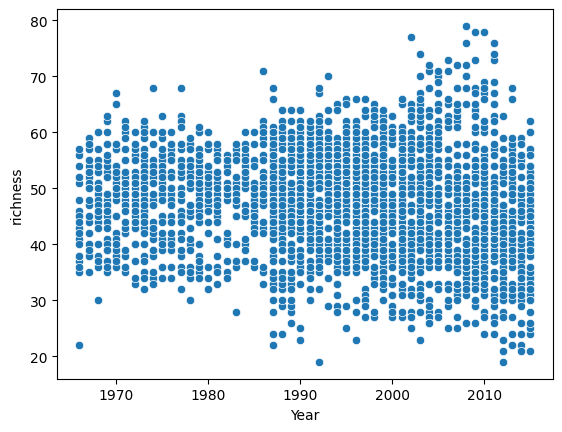

```python
import seaborn as sns
sns.scatterplot(x=df2.Year,y=df2.richness)
```

b) Now, fit a Poisson GAM with the following structure `E(richness) = exp(f(year))*exp(g(location))`. Note that location is actually two features: `Longitude` and `Latitude.` Name this model `M1.` Plot the model, get the `summary` of `M1`, and answer: Is there evidence for effects of location and year?

**ANSWER**

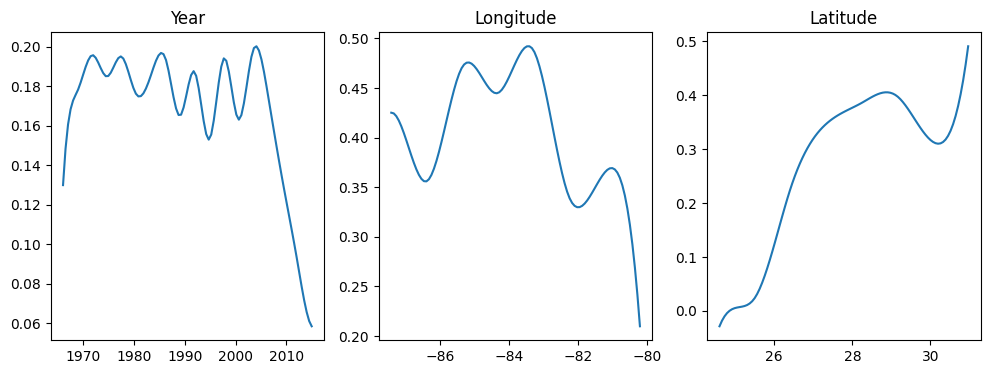

```
PoissonGAM
=============================================== ==========================================================
Distribution:                       PoissonDist Effective DoF:                                     36.8795
Link Function:                          LogLink Log Likelihood:                                 -7139.5716
Number of Samples:                         2118 AIC:                                            14352.9022
                                                AICc:                                           14354.3189
                                                UBRE:                                               3.1171
                                                Scale:                                                 1.0
                                                Pseudo R-Squared:                                   0.4016
==========================================================================================================
Feature Function                  Lambda               Rank         EDoF         P > x        Sig. Code
================================= ==================== ============ ============ ============ ============
s(0)                              [0.6]                20           19.6         1.11e-16     ***
s(1)                              [0.6]                10           8.7          0.00e+00     ***
s(2)                              [0.6]                10           8.6          0.00e+00     ***
intercept                                              1            0.0          0.00e+00     ***
==========================================================================================================
Significance codes:  0 '***' 0.001 '**' 0.01 '*' 0.05 '.' 0.1 ' ' 1

WARNING: Fitting splines and a linear function to a feature introduces a model identifiability problem
         which can cause p-values to appear significant when they are not.

WARNING: p-values calculated in this manner behave correctly for un-penalized models or models with
         known smoothing parameters, but when smoothing parameters have been estimated, the p-values
         are typically lower than they should be, meaning that the tests reject the null too readily.
```

```python
X_train, X_test, y_train, y_test = train_test_split(df2[['Year', 'Longitude', 'Latitude']], df2['richness'], test_size=0.25, random_state=42)

from pygam import PoissonGAM, s

# Creating a Poisson GAM
M1 = PoissonGAM(s(0) + s(1, n_splines=10) + s(2, n_splines=10))
M1.fit(X_train, y_train)

plt.figure()
fig, axs = plt.subplots(1, 3, figsize=(12, 4))
titles = ['Year', 'Longitude', 'Latitude']
for i, ax in enumerate(axs):
    XX = M1.generate_X_grid(term=i)
    ax.plot(XX[:, i], M1.partial_dependence(term=i, X=XX))
    ax.title.set_text(titles[i])

plt.show()

summary1 = M1.summary()
summary1
```

M1 model summary simply briefs us that:

"P > x" signifies whether the factors (Year, Longitude, and Latitude) has an impact on the outcome (richness).

**If the p-value is very low it means that there is strong evidence on richness.**

So, according to the model summary, both Year and Location (Longitude and Latitude) have a significant impact on the richness of data.

**The year and the location seem to be important in explaining the variation in richness.**

c) Now, fit another Poisson GAM model with the same structure as in `M1` , name this model `M2` but using interactions between Year, Latitude and Longitude

**ANSWER**

```python
# Creating a Poisson GAM object with interactions
M2 = PoissonGAM(te(0, 1, 2))

M2.fit(X_train, y_train)

summary2 = M2.summary()
summary2
```

```
PoissonGAM
=============================================== ==========================================================
Distribution:                       PoissonDist Effective DoF:                                    136.4675
Link Function:                          LogLink Log Likelihood:                                 -6821.7418
Number of Samples:                         2118 AIC:                                            13916.4186
                                                AICc:                                           13935.6502
                                                UBRE:                                               2.9487
                                                Scale:                                                 1.0
                                                Pseudo R-Squared:                                   0.5697
==========================================================================================================
Feature Function                  Lambda               Rank         EDoF         P > x        Sig. Code
================================= ==================== ============ ============ ============ ============
te(0, 1, 2)                       [0.6 0.6 0.6]        1000         136.5        0.00e+00     ***
intercept                                              1            0.0          0.00e+00     ***
==========================================================================================================
Significance codes:  0 '***' 0.001 '**' 0.01 '*' 0.05 '.' 0.1 ' ' 1

WARNING: Fitting splines and a linear function to a feature introduces a model identifiability problem
         which can cause p-values to appear significant when they are not.

WARNING: p-values calculated in this manner behave correctly for un-penalized models or models with
         known smoothing parameters, but when smoothing parameters have been estimated, the p-values
         are typically lower than they should be, meaning that the tests reject the null too readily.
```

d) Compare `M1` and `M2`. Note that you can use the $R^2$, AIC values, test error, among other approaches discussed in class. Which model should we select?

**ANSWER**

when the models M1 and M2 were compared.

M2 is better model as it explains more of the data.

It has a greater 𝑅² and a less AIC value.

It is impossible to compare the model with the test error as the information is not given.

M2 is the better choice but we must also think about the context and goals to make the final decision